# Lab07

Xiaoya Li

October 12, 2017

## Simple Math Functions

Write two functions f() and g() based on the previous equations.

```r
# your function f()
f <- function(x){
  z <- x ^ 2
  return(z)
}

# your function g()
g <- function(x){
  z <- 2 * x + 5
  return(z)
}
```

Test your functions with:

```r
f(2)
```

```
## [1] 4
```

```r
f(-5)
```

```
## [1] 25
```

```r
g(0)
```

```
## [1] 5
```

```r
g(-5/2)
```

```
## [1] 0
```

Write code to create the following composite functions:

```r
# your function fog()
fog <- function(x){
  z <- f(g(x))
  return(z)
}

# your function gof()
gof <- function(x){
  z <- g(f(x))
  return(z)
}
```

Test your composite functions with:

```r
fog(2)
```

```
## [1] 81
```

```r
fog(-5)
```

```
## [1] 25
```

```r
gof(0)
```

```
## [1] 5
```

```r
gof(-5/2)
```

```
## [1] 17.5
```

## Pythagoras

Write a function pythagoras() that takes two arguments a and b, and returns the length of the hypotenuse:

```r
# your pythagoras() function
pythagoras <- function(a, b){
  c <- sqrt(a ^ 2 + b ^ 2)
  return(c)
}
```

Test your pythagoras() with two leg values: pythagoras(3, 4)

```r
# your test
pythagoras(3, 4)
```

```
## [1] 5
```

Modify your function pythagoras() so that argument b takes the same value of argument a. Test it with just one leg value: pythagoras(5)

```r
pythagoras <- function(a){
  c <- sqrt(2 * a ^ 2)
  return(c)
}

# your test
pythagoras(5)
```

```
## [1] 7.071068
```

## Unit Conversion Formulas

### Miles to Kilometers

Write a function miles2kms() that converts miles into kilometers: 1 mile is equal to 1.6 kilometers. Give the argument a default value of 1.

```r
miles2kms <- function(x = 1) {
  # fill in
  z <- 1.6 * x
  return(z)
}
```

Use miles2kms() to obtain mile conversions, in order to create a table (i.e. data frame) like the one below. The first ten rows range from 1 to 10 miles, and then from 10 to 100 in 10 mile steps. The second column corresponds to kms.

```r
mile <- c(seq(1,10), seq(20,100, by = 10))
miels2kms.talbe <- data.frame(
  miles = mile,
  kms = miles2kms(mile)
)
miels2kms.talbe
```

```
##    miles   kms
## 1      1   1.6
## 2      2   3.2
## 3      3   4.8
## 4      4   6.4
## 5      5   8.0
## 6      6   9.6
## 7      7  11.2
## 8      8  12.8
## 9      9  14.4
## 10    10  16.0
## 11    20  32.0
## 12    30  48.0
## 13    40  64.0
## 14    50  80.0
## 15    60  96.0
## 16    70 112.0
## 17    80 128.0
## 18    90 144.0
## 19   100 160.0
```

### Gallons to Liters, and viceversa

Write a function gallon2liters() that converts gallons to liters: 1 gallon is equal to 3.78541 liters:

```r
# your gallons2liters() function
gallons2liters <- function(x = 1){
  z <- x * 3.78541
  return(z)
}
```

Use gallon2liters() to make an inverse function liters2gallons().

```r
# your liters2gallons() function
liters2gallons <- function(x = 1){
  z <- x / gallons2liters()
  return(z)
}
```

Use liters2gallons() to obtain liter conversions, in order to create a table (i.e. data frame) like the one below. The first ten rows range from 1 to 10 liters, and then from 10 to 100 in 10 liter steps. The second column corresponds to gallons.

```r
liter <- c(seq(1,10) , seq(20, 100, by = 10))
data.frame(
  liters = liter,
  gallons = liters2gallons(liter)
)
```

```
##    liters    gallons
## 1       1  0.2641722
## 2       2  0.5283444
## 3       3  0.7925165
## 4       4  1.0566887
## 5       5  1.3208609
## 6       6  1.5850331
## 7       7  1.8492052
## 8       8  2.1133774
## 9       9  2.3775496
## 10     10  2.6417218
## 11     20  5.2834435
## 12     30  7.9251653
## 13     40 10.5668871
## 14     50 13.2086088
## 15     60 15.8503306
## 16     70 18.4920524
## 17     80 21.1337741
## 18     90 23.7754959
## 19    100 26.4172177
```

### Seconds to Years

According to Wikipedia, in 2015 the life expectancy of a person born in the US was 79 years. Consider the following question: Can a newborn baby in USA expect to live for one billion (10 ^ 9) seconds?

To answer this question, write a function seconds2years() that takes a number in seconds and returns the equivalent number of years. Test the function with seconds2years(1000000000)

```r
seconds2years <- function(x){
  z <- x / (3600 * 24 * 365)
  return(z)
}

seconds2years(1000000000)
```

```
## [1] 31.70979
```

## Gaussian Function

Make a function gaussian() that takes three arguments: x, m, and s. Evaluate the function with m = 0, s = 2, and x = 1.

```r
gaussian <- function(x, m, s){
  g <- (1 / (s * sqrt(2 * pi))) * exp((- 1/2) * ((x - m) / s) ^ 2)
  return(g)
}

gaussian(1, 0, 2)
```

```
## [1] 0.1760327
```

Test your gaussian() function and compare it with the R function dnorm()

```r
# compare with dnorm()
dnorm(x = 1, mean = 0, sd = 2)
```

```
## [1] 0.1760327
```

Now try gaussian() with a vector seq(-4.5, 4.5, by = 0.1), and pass the values to plot() to get a normal curve. Here’s code with values obtained from dnorm()

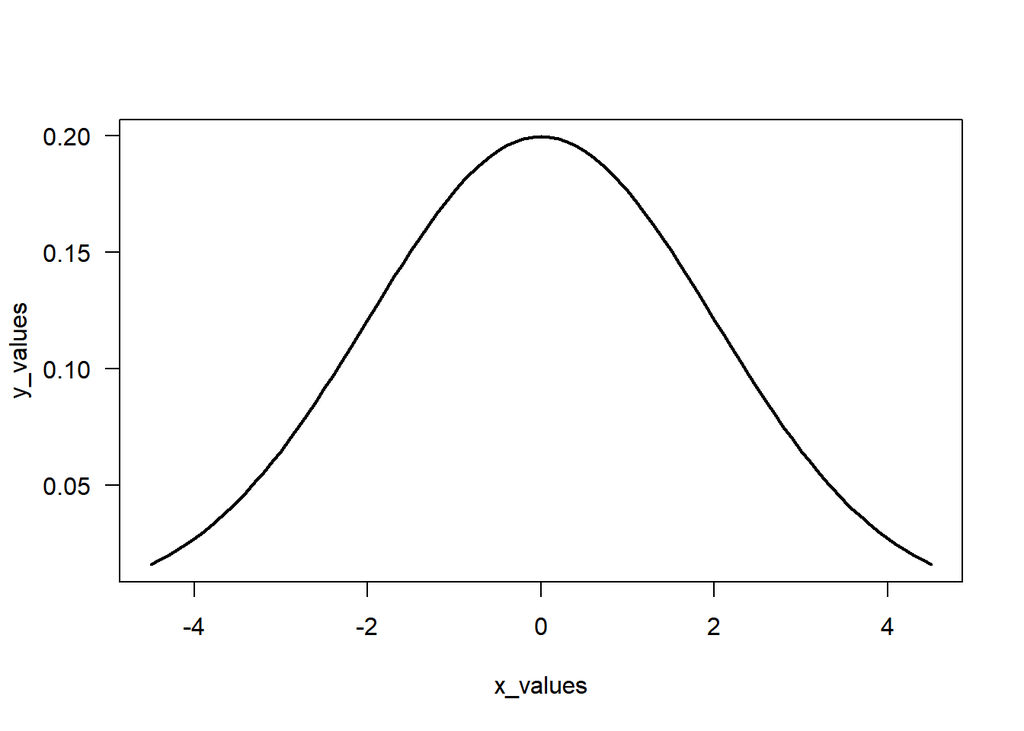

```r
# you should get a plot like this one
x_values <- seq(from = -4.5, to = 4.5, by = 0.1)
y_values <- dnorm(x_values, mean = 0, sd = 2)
plot(x_values, y_values, las = 1, type = "l", lwd = 2)
```

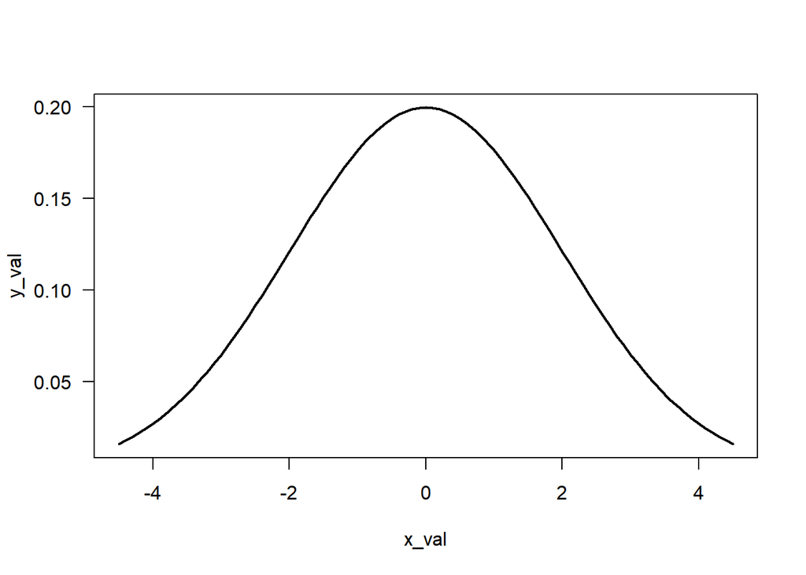

```r
# your code
x_val <- seq(-4.5, 4.5, by = 0.1)
y_val <- gaussian(x_val, 0, 2)
plot(x_val, y_val, las = 1, type = "l", lwd = 2)
```